```python
from plotnine import *
import pandas as pd

from IPython.display import display, Image
```

# Al Horford's Shooting Woes

The 76ers signed Al Horford to a four-year, $97 million contract this past summer. With him joining the likes of Ben Simmons, Joel Embiid, and Tobias Harris, Philadelphia had legitimate reason to believe the acquisition of Horford would put the 76ers over the top as title contenders for a team that was one game (and perhaps several bounces) away from knocking off the eventual champions.

Unfortunately, Al Horford's Philadelphia tenure thus far has been a disappointment, to say the least. There have been hints of [locker room issues](https://www.nbcsports.com/philadelphia/76ers/al-horford-comments-sixers-locker-room-brett-brown-nba-trade-deadline), [boos](https://www.nbcsports.com/philadelphia/76ers/sixers-fans-boos-brett-brown-joel-embiid-al-horford-shush), and his [removal from the starting lineup](https://www.cbssports.com/nba/news/76ers-decision-to-move-al-horford-to-bench-propels-them-to-impressive-win-against-clippers/).

The following analysis dives into the year-over-year shooting performance of Horford from his last season in Boston to this season in Philadelphia. The results show a dramatic degradation in shooting performance that could be cause for concern.

## Field Goal Shooting

The stats.nba.com site provides an offensive player's shooting performance by the distance to the closest defender. The NBA defines these defender distance bins as follows:

- 0-2 feet (Very Tight)
- 2-4 feet (Tight)
- 4-6 feet (Open)
- 6+ feet (Wide Open)

With Very Tight shots making up the smallest portion of Horford's frequency and the potential of those shots to be a poor indicator of shooting performance, the analysis excludes Very Tight shots. The following table shows the field goals made and attempted in each season for Al Horford.

```python
shooting_df = pd.DataFrame({'Season': ['2018-19', '2018-19', '2018-19',
                                       '2019-20', '2019-20', '2019-20'],
                            'Defender Distance': ['2-4 feet (Tight)', '4-6 feet (Open)', '6+ feet (Wide Open)',
                                                  '2-4 feet (Tight)', '4-6 feet (Open)', '6+ feet (Wide Open)'],
                            'FGM': [145, 78, 127, 88, 67, 80],
                            'FGA': [224, 146, 281, 171, 150, 214],
                            'FG%': [0.647, 0.534, 0.452, 0.515, 0.447, 0.374]})
shooting_df
```

|  | Season | Defender Distance | FGM | FGA | FG% |
| --- | --- | --- | --- | --- | --- |
| 0 | 2018-19 | 2-4 feet (Tight) | 145 | 224 | 0.647 |
| 1 | 2018-19 | 4-6 feet (Open) | 78 | 146 | 0.534 |
| 2 | 2018-19 | 6+ feet (Wide Open) | 127 | 281 | 0.452 |
| 3 | 2019-20 | 2-4 feet (Tight) | 88 | 171 | 0.515 |
| 4 | 2019-20 | 4-6 feet (Open) | 67 | 150 | 0.447 |
| 5 | 2019-20 | 6+ feet (Wide Open) | 80 | 214 | 0.374 |

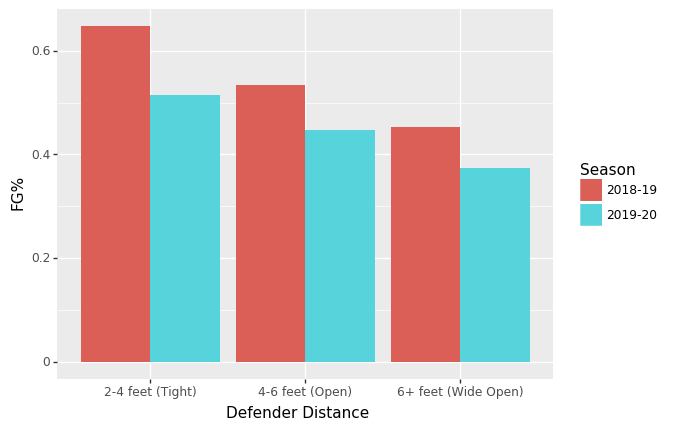

```python
p1 = ggplot(shooting_df) + \
  geom_col(mapping = aes(x='Defender Distance', y='FG%', fill='Season'), position='dodge')
p1
```

The above figure shows that Horford has suffered a sizable drop in field goal percentage across the defender distance bins shown. Especially troubling is that open and wide open shots are not immune. If Horford were strictly struggling when closely guarded, a degradation in pure shooting skill would be less likely.

But is the above especially concerning? The season is only about halfway through, and the chart does not provide any context into this drop in field goal percentage. If many players experience similar or greater fluctuations in shooting percentage year-over-year, Horford's performance could also be less of a long-term issue. The following charts contain players with at least 100 field goal attempts from each defender distance bin in 2018-19 and 75 field goal attempts from each defender distance bin in 2019-20.

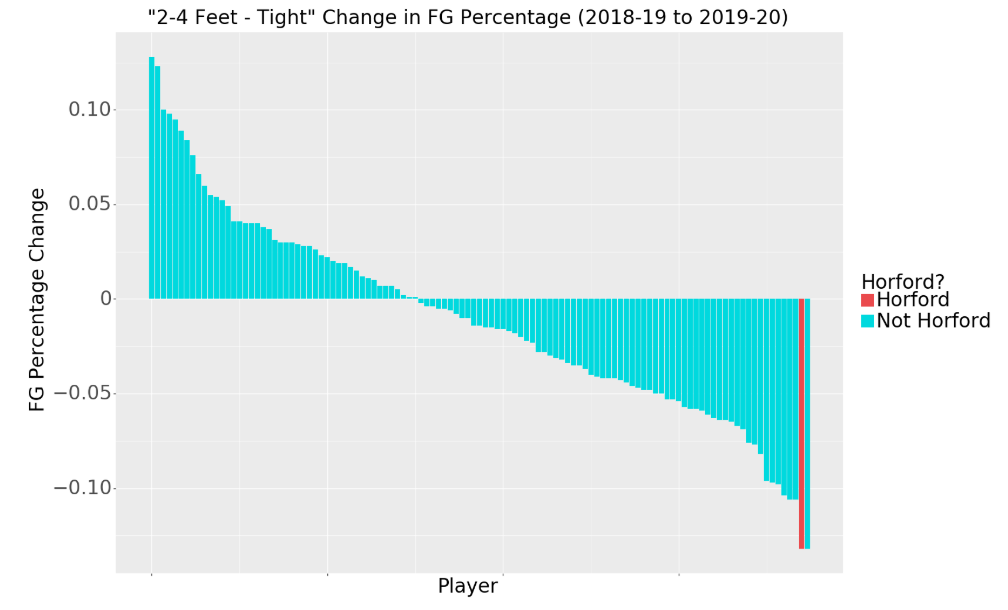

```python
display(Image(filename='images/tight.png', width=1200))
```

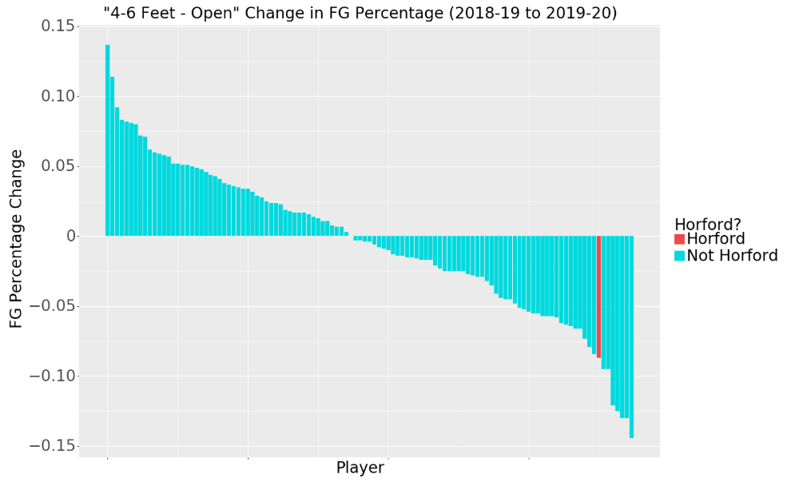

```python
display(Image(filename='images/open.png', width=1200))
```

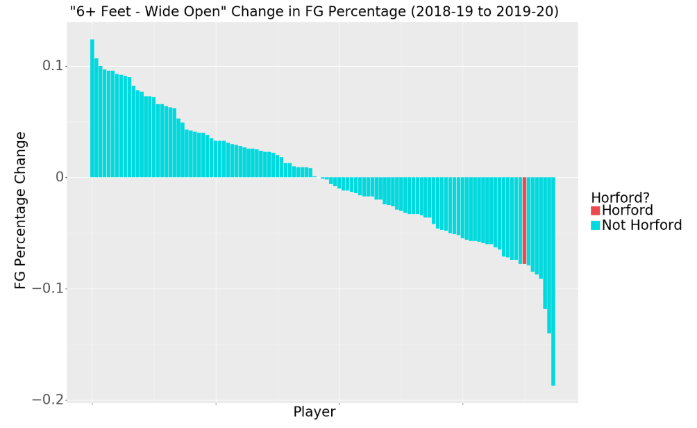

```python
display(Image(filename='images/wide_open.png', width=1200))
```

Horford is clearly bothered the most this year when closely-guarded as he is tied for last in the league among qualified players. Equally concerning is the fact that Horford is in the bottom-10 of qualified players on both Open and Wide Open shots. With such a drastic drop in shooting percentage across all defender distance bins relative to the league, one could reasonably conclude that Horford's shooting skill has declined greatly this year.

While the above is convincing, shots from the field have additional factors that impact the probability of a successful shot. Horford's open shots could be drifting further from the basket and tight shots could be guarded by better defenders. A large sample lessens this point a bit, but examining free throws might provide conclusive evidence.

## Free Throw Shooting

The following table shows the free throws made and attempted in 2018-19 and 2019-20 seasons for Al Horford.

```python
shooting_df = pd.DataFrame({'Season': ['2018-19', '2019-20'],
                            'FTM': [78, 41],
                            'FTA': [95, 56],
                            'FT%': [0.821, 0.732]})
shooting_df
```

|  | Season | FTM | FTA | FT% |
| --- | --- | --- | --- | --- |
| 0 | 2018-19 | 78 | 95 | 0.821 |
| 1 | 2019-20 | 41 | 56 | 0.732 |

Modeling free throw attempts as a Bernoulli process and leveraging bootstrap hypothesis testing as done for [this post](https://basketballrelativity.github.io/personal/embiid_injury) on Joel Embiid can provide a sense of the significance for Horford's decrease in free throw percentage.

The following figure shows distributions of the FT% formed by 1000 samples with replacement from Horford's attempted free throws.

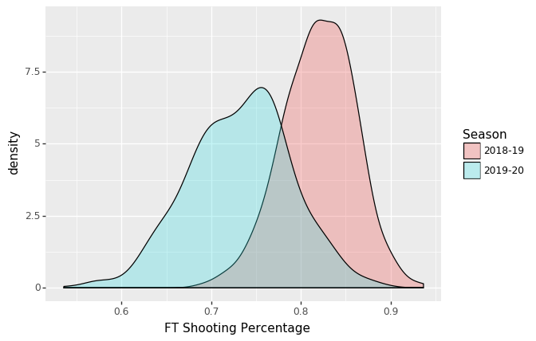

```python
display(Image(filename='images/horford_ft.png', width=600))
```

The p-value from the bootstrap hypothesis testing is 0.084, just shy of the standard threshold of the 0.05 significance level to reject the hypothesis that Horford's underlying free throw shooting skill has not changed from 2018-19 to 2019-20. Unfortunately, Horford does not get to the line very often, so the variance in the bootstrapped distributions is high, which harms the ability to make definitive conclusions.

# Takeaways

The above suggests that Al Horford seems to have suffered a systematic decline in both field goal and free throw shooting in just one year. Horford is bottom-10 in the league among qualified players on year-over-year change in field goal percentage from all defender distance bins considered in this analysis. Additionally, Horford lost nearly 10 percentage points from his free throw percentage, which is very close to a statisically significant change. However, the performance from the field lends credibility to the notion that his change in free throw percentage is troubling.

Through the lens here, one could reasonably conclude that Horford is markedly worse than last year. The analysis does not consider why such a change has occurred, which could be caused by many factors, such as age, shot selection, teammates, or opposition. This is not the version of Al Horford the 76ers believed would contribute to a title run this season.